# Data Cleaning Methods: A Tutorial

Eilif Mikkelsen

# Introduction

In an academic setting data sets are often presented as clean and orderly sets of information. For most real-world applications this couldn’t be farther from the truth. When talking to data scientists across industries it is commonly noted that the vast majority of their time is spent cleaning and structuring data before they can even consider models.

In this tutorial we will cover some core data cleaning methods. This is by no means exhaustive however it should leave the reader with a strong set of data manipulation skills. For context, I wrote this document to hone my data manipulation skills in R after spending the last couple years working with the [Python Pandas](https://pandas.pydata.org/) data library which provides data structures and features similar to the R `data.frame` object. Periodically, comments detailing the `pandas` equivalents will be included looking something like `# Py/Pandas: df.head()`.

This document was originally written in R Markdown, a format for generating mixed format documents combining code and text. Where it seems useful, I will include links to relevent packages or functions. Here is a link to a [cheat sheet](https://www.rstudio.com/wp-content/uploads/2015/02/rmarkdown-cheatsheet.pdf) on the R Markdown syntax.

New commands introduced in a section will be listed in the “Commands Used” sub-section at the beginning of each topic.

This is a How-To document, NOT academic writing. Read it that way and have some fun with your data.

# What is Presumed About the Reader

- The reader has a very basic understanding of simple programming concepts.
- The reader is has cursory knowledge of the [`data.frame`](https://www.rdocumentation.org/packages/base/versions/3.4.3/topics/data.frame) tabular data structure and its methods.
- The reader remembers that arrays in R are 1-indexed rather than 0-indexed.

I will use `=` rather than `<-` out of habit from my work in Python. So far as I can tell, they are equivalent.

If you wish to follow along you will need R and R Studio installed.

# Setup

Here is the output information on the operating system and R version used to generate this tutorial. This tutorial uses R builtins and some well tested additional packages. If you find issues, please feel free to edit this file and submit a pull request to this repository. Where specific packages are required, additional notes will be made.

```r
version
```

```
               _
platform       x86_64-apple-darwin13.4.0
arch           x86_64
os             darwin13.4.0
system         x86_64, darwin13.4.0
status
major          3
minor          3.3
year           2017
month          03
day            06
svn rev        72310
language       R
version.string R version 3.3.3 (2017-03-06)
nickname       Another Canoe
```

# Topics Covered

- Cleaning string categories
- Context aware string categorization
- Basic regular expressions
- Basic aggregation
- Context aware unit standardization
- Datetime parsing
- Mixed data type columns

# The Data

I once had a professor that said that no matter how good and experienced and smart we are, there is no substitute for viewing and plotting your data!

## Commands Used

- [`hist`](https://www.rdocumentation.org/packages/graphics/versions/3.4.3/topics/hist) [^1]
- [`read.csv`](https://www.rdocumentation.org/packages/utils/versions/3.4.3/topics/read.table) [^2]
- [`row.names`](https://www.rdocumentation.org/packages/base/versions/3.4.3/topics/row.names) [^3]
- [`head`](https://www.rdocumentation.org/packages/utils/versions/3.4.3/topics/head) [^4]
- [`nrow`](https://www.rdocumentation.org/packages/base/versions/3.4.3/topics/nrow) [^5]
- [`ncol`](https://www.rdocumentation.org/packages/base/versions/3.4.3/topics/nrow) [^6]

## Data Generation

All the source code for the generation of the bad data and the original markdown for this tutorial can be found at https://github.com/eilifm/rit_missing_data/tree/master/data_cleaning_tutorials.

The dataset is a artificially generated set of blood alcohol concentration (BAC) observations including a collection of other variables that may or may not be used in the computation of BAC. This includes information about the weight, age, sex, number of drinks, and type of alcohol consumed for each fake participant. BAC is computed according to NIH standards found [here](http://www.ndaa.org/pdf/toxicology_final.pdf)[^7]

## The Data

Let’s start by loading and looking at the first few rows of the data. The ix columns is an arbitrary row number that was created along with the dataset. We will use this to uniquely identify rows. Additionally, we want all string columns to be treated as characters rather than “factors”, a special R data type.

```r
library(ggplot2)
# Loading the CSV
# Py/Pandas: pd.read_csv('./horrible_data.csv', index=0)
in_data = read.csv('./horrible_data.csv', stringsAsFactors=FALSE)
# Let's duplicate the data so we can keep a copy of the original.
# When we update data we will update wrk_data not in_data
wrk_data = cbind(in_data)
# Setting the row names to the `ix` column
row.names(in_data) = in_data$ix
# Py/Pandas: df.head()
head(in_data)
```

|  | X | BAC | age | collection_date | drink_type | num_drinks | sex | units | volume_consumed | weight |
| --- | --- | --- | --- | --- | --- | --- | --- | --- | --- | --- |
| 1 | 0 | 0.09797274 | 314 | 2018-03-20T22:52:36.496113 | shots | 3.8 | meal | metric | 169.3947 | 75.64277 |
| 2 | 1 | 0.12523301 | 1993-01-29 | 2018-03-20T22:52:36.498368 | Beer | 6.0 | meal |  | 72.0000 | 202.36000 |
| 3 | 2 | 0.13997770 | 1984-06-02 | 2018-03-20T22:52:36.498606 | Cab | 3.7 | F |  | 18.5000 | 150.10000 |
| 4 | 3 | 0.07066611 | 463 | 2018-03-20T22:52:36.498777 | vidka | 2.0 | female |  | 3.0000 | 155.59000 |
| 5 | 4 | 0.04741322 | 717 | 2018-03-20T22:52:36.498951 | Scotch | 2.1 | M | metric | 93.2125 | 93.40905 |
| 6 | 5 | 0.22823374 | 1982-05-02 | 2018-03-20T22:52:36.499121 | whiskey | 6.3 | female |  | 9.4500 | 158.71000 |

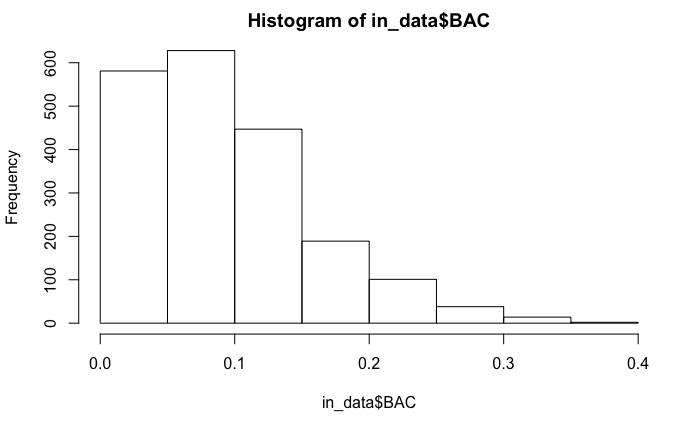

```r
# Let's use the super handy built-in to generate a histogram
hist(in_data$BAC)
```

```r
# Let's also look at the overall shape of the dataset.
nrow(in_data)
```

```
[1] 2000
```

```r
ncol(in_data)
```

```
[1] 10
```

# Standardizing Text (string) Columns

When faced with text variables, figuring out how to group and organize the values into usable data can be extremely time consuming and difficult.

Immediately upon observing the first 6 rows of the data we see that there are several variations of the same category for both the `units` and `sex` column. The goal is to identify what values in the column correspond to what categories. The `drink_type` column also needs to be cleaned in a similar manner but it requires additional discussion.

I used [this](https://www.statmethods.net/management/subset.html) review of R subsetting methods to brush up for this tutorial. Be sure to also remeber that a dataframe has two dimensions, rows and columns. Let `rdf` be an R data frame. If we wish to select the first column for all observations (rows) we would call `rdf[, 1]` as dataframe selecting follows [row, column] convention.

## Commands Used:

- [`unique`](https://stat.ethz.ch/R-manual/R-devel/library/base/html/unique.html)
- [`which`](https://stat.ethz.ch/R-manual/R-devel/library/base/html/which.html)
- [`c`](https://stat.ethz.ch/R-manual/R-devel/library/base/html/c.html)
- [`qplot`](https://www.rdocumentation.org/packages/ggplot2/versions/2.2.1/topics/qplot)

Let’s print out the list of unique items in the sex column

```r
sex_vals = unique(in_data$sex)
sex_vals
```

```
[1] "meal"   "F"      "female" "M"      "male"   "Male"   "femeal" ""       "Female"
```

Conditional indexing allows for the selection of rows based on matching column conditions. For those readers familiar with general programming methods, this is essentially the creation of a binary mask. Here we will look for the rows where the `sex` column equals “Male”. We can make these masks as elaborate as required by combining boolean criteria with `&` and `|`.

```r
# Selecting rows where
head(in_data[which(in_data$sex == "Male"), ])
```

|  | X | BAC | age | collection_date | drink_type | num_drinks | sex | units | volume_consumed | weight |
| --- | --- | --- | --- | --- | --- | --- | --- | --- | --- | --- |
| 10 | 9 | 0.019143507 | 753 | 2018-03-20T22:52:36.499810 | Merlot | 0.8 | Male | metric | 116.9383 | 80.78506 |
| 13 | 12 | 0.055389046 | 1955-08-31 | 2018-03-20T22:52:36.500287 | shots | 2.0 | Male |  | 3.0000 | 186.50000 |
| 15 | 14 | 0.006089396 | 1960-07-07 | 2018-03-20T22:52:36.500619 | whiskey | 0.4 | Male |  | 0.6000 | 177.63000 |
| 21 | 20 | 0.075685044 | 382 | 2018-03-20T22:52:36.501756 | Vin | 3.2 | Male |  | 16.0000 | 192.89000 |
| 22 | 21 | 0.035691226 | 1953-09-09 | 2018-03-20T22:52:36.501923 | Cab | 1.6 | Male |  | 8.0000 | 182.79000 |
| 28 | 27 | 0.105036672 | 530 | 2018-03-20T22:52:36.502970 | Beer | 5.1 | Male | metric | 1811.8782 | 105.59537 |

What is the which command doing? It is applying the boolean filters provided and returning the row numbers/names of the rows for which the filters return TRUE. If we print out the results of the which command we can see this.

```r
head(which(in_data$sex == "Male"))
```

```
[1] 10 13 15 21 22 28
```

We see from the output that this dataset has two correct options for `sex`, Male and Female. We also observe that the dataset contains a variety of abbreviations and typos for the two categories. To standardize the values such that all observations that should be recorded as Male are updated accordingly. We will perform the same operation for Female.

To accomplish this task, we will need to use the `%in%` operator. The `%in%` operator checks if a value is in the supplied set. In a pseudocode example let `s = {1, 3, 6}`. The evaluation of `1 in s` returns `TRUE` while `2 in s` returns `FALSE`.

```r
# A vector of all the values that should be classified as "Male"
male_values = c("Male", "meal", "male", "M")
# Now we will use the `%in%` operator to select all rows where the `sex` column value is
# in the set of possible values.
head(in_data[which(in_data$sex %in% male_values), c("BAC", "sex")], n = 10)
```

|  | BAC | sex |
| --- | --- | --- |
| 1 | 0.097972742 | meal |
| 2 | 0.125233014 | meal |
| 5 | 0.047413216 | M |
| 7 | 0.057429282 | M |
| 8 | 0.081582995 | male |
| 10 | 0.019143507 | Male |
| 13 | 0.055389046 | Male |
| 15 | 0.006089396 | Male |
| 17 | 0.071252298 | male |
| 18 | 0.059989811 | M |

Now that we know how to select the rows that need to be updates, we can update wrk_data directly. We can set a column of the filtered dataframe to a value and only the selected rows will be updates.

```r
wrk_data[which(wrk_data$sex %in% male_values), "sex"] = "Male"
# Let's do the same thing for "Female"
female_values = c("F", "female", "Female", "femeal")
wrk_data[which(wrk_data$sex %in% female_values), "sex"] = "Female"
```

```r
# SUCCESS! If we examine the unique set of values for `sex` in wrk_data
# we see that Male and Female are now standardized.
unique(wrk_data$sex)
```

```
[1] "Male"   "Female" ""
```

If you aren’t careful you may have missed that there was a value in the `sex` column of `""` or nothing. Since we suspect that `sex` has impact on on the BAC with all things equal, let’s plot `num_drinks` vs `BAC` and color the data points based on `sex`.

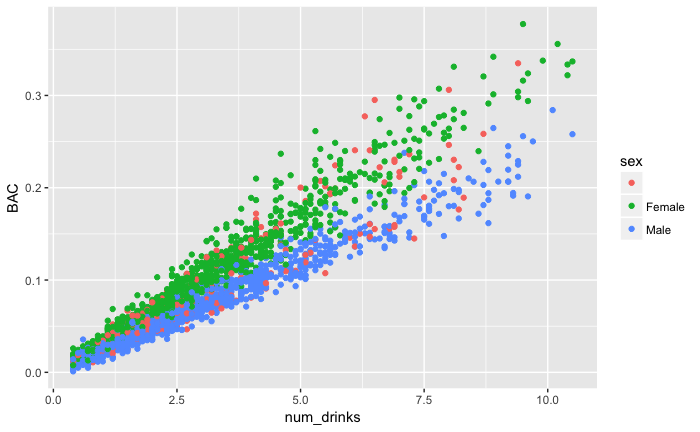

```r
qplot(num_drinks, BAC, colour = sex,
   data = wrk_data)
```

Whoa, there appears to be a clear difference between `Male` and `Female`. Given this difference we have two choices about how to handle the missing `sex` values. The simple option would be to simply drop the missing values. We will do this right before we fit our model. If you are interested in seeing how one might impute these values, see the appendix.

## Cleaning `units`

Alright! We have learned how to update rows/columns in a dataframe using boolean masking. The `units` column has similar issues. I won’t go through the explanation again but the steps are the same as those for `sex` above.

```r
# Let's print out the list of unique items in the units column
unique(in_data$units)
```

```
[1] "metric" ""       "SI"
```

```r
metric_values = c("metric", "SI")
wrk_data[which(wrk_data$units %in% metric_values), "units"] = "metric"
# It's bad practice to have the absense of information imply a definitive value.
# I know (because I made the dataset) that all values that are not marked as metric
# use the America/imperial units.
wrk_data[which(!(wrk_data$units %in% metric_values)), "units"] = "imperial"
# Let's check our work.
unique(wrk_data$units)
```

```
[1] "metric"   "imperial"
```

## `drinks_type`: A Demonstration in Data Context

Before I go into what the values for this column mean, let’s start by just looking at them. What do you notice?

```r
unique(wrk_data$drink_type)
```

```
 [1] "shots"                  "Beer"                   "Cab"                    "vidka"                  "Scotch"                 "whiskey"
 [7] "Merlot"                 "Bud Light"              "Wine"                   "Warsteiner"             "Vin"                    "Vino"
[13] "Franziskaner Weissbier" "IPA"
```

What we have here is known in the industry as a “hot mess”. If you didn’t guess, the values are a mix of alcoholic beverage brands and types in a variety of languages. When encountering this sort of data, it’s often worth taking the 20 mins. to go an Google each item.

I am not well read in the boozes of the world. A quick Google search reveals that “Warsteiner” and “Franziskaner Weissbier” are beer. Once we know what everything is we can generate our list of categories and assign the options to a specific category as we did with `sex` and `units`

The resulting code would look something like this.

```r
# Vectors for each type of alcoholic beverage.
wine_options = c("Merlot", "Vino", "Vin", "Cab")
beer_options = c("Bud Light", "IPA", "Beer", "Franziskaner Weissbier", "Warsteiner")
hard_liquor_options = c("shots", "Scotch", "whiskey", "vidka")
wrk_data[which(wrk_data$drink_type %in% wine_options), "drink_type"] =
  "Wine"
wrk_data[which(wrk_data$drink_type %in% beer_options), "drink_type"] =
  "Beer"
wrk_data[which(wrk_data$drink_type %in% hard_liquor_options), "drink_type"] =
  "Hard Liquor"
unique(wrk_data$drink_type)
```

```
[1] "Hard Liquor" "Beer"        "Wine"
```

# DateTime Parsing and Computation

In this section we will clean up the `collection_date` and `age` columns, discuss the importance of correct data typing, and demonstrate datetime operations in R.

## Commands Used

- [`anytime`](https://cran.r-project.org/web/packages/anytime/index.html)
- [`typeof`](https://www.rdocumentation.org/packages/base/versions/3.4.3/topics/typeof)
- [`as.POSIXct`](https://www.rdocumentation.org/packages/dwtools/versions/0.8.3.9/topics/as.POSIXct)
- [`as.Date`](https://www.rdocumentation.org/packages/date/versions/1.2-38/topics/as.date)

## Packages Used

- [`anytime`](https://cran.r-project.org/web/packages/anytime/index.html). This can be installed from your favorite R session using `install.packages("anytime")`
- [`lubridate`](https://www.rdocumentation.org/packages/lubridate/versions/1.7.3/topics/lubridate-package)

## A Brief Introduction to Why Data Types Matter

Every column in the loaded dataframe `in_data` has a data type. Without going too far into what this means know that the type of a column influences how R, and the code we write for it, process the data. Imagine we have the data value `01776`. This set of digits/characters could mean a variety of completely unrelated things. For example `01776` could be:

- The string Zip Code for Sudbury, Massachusetts
- The year in which the Declaration of Independence of the United States of America was signed but for some reason the number was padded with a zero.
- An arbitrary integer measurement where the padded zero was included to indicate that the maximum value is 99999.

If this value was a Zip Code then we must tell R that under no circumstance should the numerical value be considered. The string `01778` is a code of characters, not a number. If the value was a year, we may consider forcing R to treat it as a string, date, or integer depending on the application. If the value was a measurement, we would want it to be considered a float or an integer.

Before we can perform operations on entire columns we must first unify the data types within the column.

There is a lot more than can be said on data types and “type safety” in programming. If you’re interested in reading more about this be prepared for a fierce internet debate between programming communities.

Back to the examples at hand…

## Setting data type for `collection_date`

In this example dataset we have two columns that need additional attention to their types, `collection_date`, the data of data collection, and `age`, the age of the participant at the time of the study. If we examine the `collection_date` column we can observe that the values are “string encoded dates” or a representation of a date and time using a standard string format. Here, the dates are represented using the [ISO 8601](https://en.wikipedia.org/wiki/ISO_8601) date format. We will use the `anytime` package which is excellent for automatically parsing standard date formats into the datetime datatypes in R. We will also be using `lubridate` and a custom function.

```r
# Load the datetime utilities libraries
library(lubridate)
library(anytime)
# Examine the type of the collection_date column. Note that R currently classifies
# it as "character"
typeof(in_data$collection_date)
```

```
[1] "character"
```

```r
# Use anytime to convert the column to POSIXct times.
wrk_data[,'collection_date'] = anydate(wrk_data$collection_date)
# Note that the type has changed to "double", don't worry, this is really a datetime.
typeof(wrk_data$collection_date)
```

```
[1] "double"
```

```r
wrk_data$collection_date[1]
```

```
[1] "2018-03-20"
```

Why does this matter?

Suppose I wanted to compute the time between a value in the column and some other date. I could try to type out the dates as strings and pray that the compute knows what I mean. This won’t work because the subtraction of two string types has no idea what you intended to do! You could also transform the dates from your colloquial format to some relative time unit like “fortnights since 1/1/2000” but this will quickly become cumbersome and error prone. By having two values that are typed as datetime, R knows about all the leap years, time zones, and other quirks and is able to correctly perform time operations without any effort from the user.

```r
# Let's just type out the dates and try to subtract them.... ERROR
# "2011-03-25" - "2001-03-25"
# Now let's try a computation of two datetime objects.
as.Date("2018-05-19") - wrk_data$collection_date[1]
```

```
Time difference of 60 days
```

Tada! Using datetime objects gives a correct and useful result.

## A Brief Aside on Regular Expressions (Regex)

https://www.rstudio.com/wp-content/uploads/2016/09/RegExCheatsheet.pdf

## Using Regex to Sort Out `age`

Looking at the first 10 values in the `age` column we can see immediately that the type is mixed. Some of the values are the age in **months** while others are the birthday. Yikes!

```r
head(in_data$age, n = 10)
```

```
 [1] "314"        "1993-01-29" "1984-06-02" "463"        "717"        "1982-05-02" "409"        "595"        "1960-05-14" "753"
```

To select the rows where the `age` column contains a birthdate rather than an age, we need to match the values that follow the pattern `YYYY-MM-DD`. In regex for R, this is `'^(\\d{4})-(\\d{2})-(\\d{2})'`.

For these examples we will be exploring the features of the `lubridate` package.

```r
head(wrk_data$age)
```

```
[1] "314"        "1993-01-29" "1984-06-02" "463"        "717"        "1982-05-02"
```

```r
# If we run grep along the column, it returns the row number of the matching columns
grep('^(\\d{4})-(\\d{2})-(\\d{2})', wrk_data$age, perl = TRUE)[1:10]
```

```
 [1]  2  3  6  9 11 12 13 15 16 18
```

```r
# Let's make a vector of these
birthdate_rows = grep(
                    '^(\\d{4})-(\\d{2})-(\\d{2})',
                    in_data$age,
                    perl = TRUE)
# Let's look at the values
in_data[birthdate_rows, "age"][1:10]
```

```
 [1] "1993-01-29" "1984-06-02" "1982-05-02" "1960-05-14" "1965-02-16" "1987-12-19" "1955-08-31" "1960-07-07" "1961-05-06" "1956-02-08"
```

We will also need a function to convert the time between the birthday and collection date to months.

```r
months_between <- function(end_date, start_date) {
    end_dt <- as.POSIXlt(end_date)
    start_dt <- as.POSIXlt(start_date)

    # 12 times the elapsed years + the elapsed months intrayear
    return(12 * (end_dt$year - start_dt$year) + (end_dt$mon - start_dt$mon))
}
# Test it
months_between("2016-02-23", "2015-01-28")
```

```
[1] 13
```

Phew! Now let’s put it all together.

```r
head(wrk_data$age)
```

```
[1] "314"        "1993-01-29" "1984-06-02" "463"        "717"        "1982-05-02"
```

```r
wrk_data$age = in_data$age
# Compute months_between, convert to strings, update the dataframe
wrk_data[birthdate_rows, "age"] =
                          as.character(
                          months_between(
                            in_data[birthdate_rows, "collection_date"],
                            in_data[birthdate_rows, "age"]
                            )
                          )
# Convert the now-uniform column to numeric values
wrk_data[, 'age'] = as.integer(wrk_data$age)
# Convert months to decimal years
wrk_data[, 'age'] = wrk_data[, 'age']/12
head(wrk_data[, 'age'])
```

```
[1] 26.16667 25.16667 33.75000 38.58333 59.75000 35.83333
```

```r
head(wrk_data)
```

|  | X | BAC | age | collection_date | drink_type | num_drinks | sex | units | volume_consumed | weight |
| --- | --- | --- | --- | --- | --- | --- | --- | --- | --- | --- |
| 1 | 0 | 0.09797274 | 26.16667 | 2018-03-20 | Hard Liquor | 3.8 | Male | metric | 169.3947 | 75.64277 |
| 2 | 1 | 0.12523301 | 25.16667 | 2018-03-20 | Beer | 6.0 | Male | imperial | 72.0000 | 202.36000 |
| 3 | 2 | 0.13997770 | 33.75000 | 2018-03-20 | Wine | 3.7 | Female | imperial | 18.5000 | 150.10000 |
| 4 | 3 | 0.07066611 | 38.58333 | 2018-03-20 | Hard Liquor | 2.0 | Female | imperial | 3.0000 | 155.59000 |
| 5 | 4 | 0.04741322 | 59.75000 | 2018-03-20 | Hard Liquor | 2.1 | Male | metric | 93.2125 | 93.40905 |
| 6 | 5 | 0.22823374 | 35.83333 | 2018-03-20 | Hard Liquor | 6.3 | Female | imperial | 9.4500 | 158.71000 |

# Units Conversions

Data is often collected in different places under different measurement systems. In this section we will look at how the reader might be able to figure out what units were used and how to perform the unit conversions.

## Commands Used

- [`as.factor`](https://www.rdocumentation.org/packages/h2o/versions/3.16.0.2/topics/as.factor)
- [`aggregate`](https://www.rdocumentation.org/packages/stats/versions/3.4.3/topics/aggregate)

## Unit Discovery and Metric to Imperial Conversions

We know that there is a discriminator column called “units” which tells us what unit system was used. The two measurement values in the dataset are `weight` and `volume_consumed`. If we create box-whisker plot for `volume_consumed` for each unit system we can see the difference clearly.

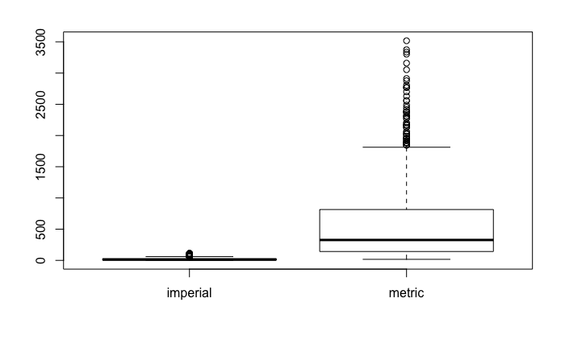

```r
# Box and Whisker plot of volume_consumed by unit type
plot(as.factor(wrk_data$units), in_data[, "volume_consumed"])
```

As the author of the original dataset, I can disclose that the volume units for `metric` are milliliters while the `imperial` units are ounces. The best way to examine the relationship between `metric` and `imperial` units is by using data aggregation. Aggregating operations require a set of columns to sum/count/mean based on a categorical variable. We can see the relationship between units by taking ratio of the average volume per unit type. We know that there are 29.6 ml in an ounce. The ratio should be right around this number. We can do the same for the weight where the `metric` units are kg and the `imperial` units are lbs.

```r
# Let's aggregate the volume and weight numbers by their respective units
# and take the mean
volume_means = aggregate(
                    wrk_data[, c("volume_consumed", "weight")],
                    list(units = wrk_data$units),
                    mean)
volume_means
```

| units | volume_consumed | weight |
| --- | --- | --- |
| imperial | 19.43415 | 178.37859 |
| metric | 581.70650 | 80.57445 |

```r
# Ratio of the metric volume mean to the imperial volume mean
volume_means[which(volume_means$units == "metric"),  "volume_consumed"] /
  volume_means[volume_means$units == "imperial",  "volume_consumed"]
```

```
[1] 29.93218
```

```r
# Ratio of the metric weight mean to the imperial weight mean
volume_means[which(volume_means$units == "metric"),  "weight"] /
  volume_means[volume_means$units == "imperial",  "weight"]
```

```
[1] 0.4517047
```

The computed BAC in this dataset used `imperial` units so we we must convert the `metric` values back to `imperial`.

```r
# Convert volume - ml to oz
wrk_data[which(wrk_data$units == 'metric'), "volume_consumed"] =
  wrk_data[which(wrk_data$units == 'metric'), "volume_consumed"]/29.6
head(wrk_data[which(wrk_data$units == 'metric'), "volume_consumed"])
```

```
[1]  5.722793  3.149071 11.047757  3.950618 22.812369  3.615657
```

```r
# Convert weight - kg to lbs
wrk_data[which(wrk_data$units == 'metric'), "weight"] =
  wrk_data[which(wrk_data$units == 'metric'), "weight"]/.453592
head(wrk_data[which(wrk_data$units == 'metric'), "weight"])
```

```
[1] 166.7639 205.9319 187.3555 178.1007 163.0126 159.2476
```

## Convert `volume_consumed` to alcohol consumed

As we all learned in health class, different types of alcoholic beverage contain different quantities of alcohol. If we plot the `volume_consumed` for each of the `drink_types` we can clearly see the difference in volume consumed depending on the type of drink.

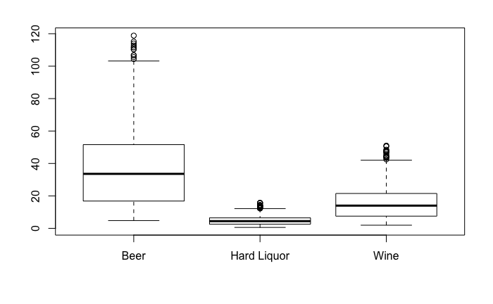

```r
plot(as.factor(wrk_data$drink_type), wrk_data$volume_consumed)
```

Since the number of “drinks” is supplied in the dataset, we do not need to convert the volume to ounces. The best way to do this would be to multiply the volumes by their ABV (Alcohol by Volume) percentages. We don’t need this column fixed to build our model so this is a good one for me to leave as practice for you, the reader.

# Final Preparations and Modeling!

## Commands Used

- [`lm`](https://www.rdocumentation.org/packages/stats/versions/3.4.3/topics/lm)

```r
# Make a copy to use in the appendix
impute_data = wrk_data
```

```r
# Remove all rows where sex is blank
wrk_data = wrk_data[!(wrk_data$sex == ""),]
head(wrk_data)
```

|  | X | BAC | age | collection_date | drink_type | num_drinks | sex | units | volume_consumed | weight |
| --- | --- | --- | --- | --- | --- | --- | --- | --- | --- | --- |
| 1 | 0 | 0.09797274 | 26.16667 | 2018-03-20 | Hard Liquor | 3.8 | Male | metric | 5.722793 | 166.7639 |
| 2 | 1 | 0.12523301 | 25.16667 | 2018-03-20 | Beer | 6.0 | Male | imperial | 72.000000 | 202.3600 |
| 3 | 2 | 0.13997770 | 33.75000 | 2018-03-20 | Wine | 3.7 | Female | imperial | 18.500000 | 150.1000 |
| 4 | 3 | 0.07066611 | 38.58333 | 2018-03-20 | Hard Liquor | 2.0 | Female | imperial | 3.000000 | 155.5900 |
| 5 | 4 | 0.04741322 | 59.75000 | 2018-03-20 | Hard Liquor | 2.1 | Male | metric | 3.149071 | 205.9319 |
| 6 | 5 | 0.22823374 | 35.83333 | 2018-03-20 | Hard Liquor | 6.3 | Female | imperial | 9.450000 | 158.7100 |

```r
model_data = wrk_data
model_data = model_data[, !(names(model_data) %in% c(
                                                      "collection_date",
                                                      "units",
                                                      "volume_consumed",
                                                      "X",
                                                      "drink_type"
                                                      )
                            )
                        ]
```

## Looking at Clean Data

This serves both to understand the dataset and demonstrate various plotting methods. Specifically, let’s look at how the variables relate to `sex` and `bac`

```r
library(ggpubr)
# Box plot of sex and weight
p1 = qplot(sex, weight, color = sex, data = model_data, geom = "boxplot")
# Box plot of sex and BAC
p2 = qplot(sex, BAC, color = sex, data = model_data, geom = "boxplot")
# Scatter plot of num_drinks and BAC
p3 = qplot(num_drinks, BAC, colour = sex,
   data = model_data)
# Scatter plot of weight and BAC
p4 = qplot(weight, BAC, color=sex, data = model_data)
```

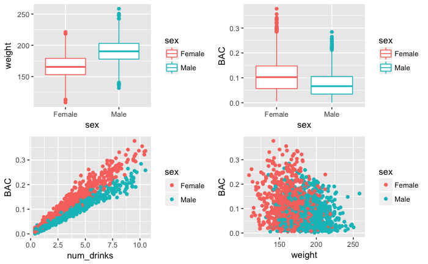

```r
ggarrange(p1, p2, p3, p4)
```

## Fit a Linear Regression Model

```r
model_data$sex = ifelse(model_data$sex == "Male", 1, 0)
lm1 = lm(BAC ~ ., data = model_data)
summary(lm1)
```

```
Call:
lm(formula = BAC ~ ., data = model_data)

Residuals:
      Min        1Q    Median        3Q       Max
-0.052862 -0.007927 -0.000629  0.006778  0.074764

Coefficients:
              Estimate Std. Error t value Pr(>|t|)
(Intercept)  1.043e-01  3.258e-03  32.032   <2e-16 ***
age         -3.791e-05  3.035e-05  -1.249    0.212
num_drinks   2.853e-02  1.846e-04 154.565   <2e-16 ***
sex         -2.014e-02  7.664e-04 -26.272   <2e-16 ***
weight      -5.074e-04  1.655e-05 -30.662   <2e-16 ***
---
Signif. codes:  0 ‘***’ 0.001 ‘**’ 0.01 ‘*’ 0.05 ‘.’ 0.1 ‘ ’ 1

Residual standard error: 0.01385 on 1780 degrees of freedom
Multiple R-squared:  0.9536,    Adjusted R-squared:  0.9534
F-statistic:  9136 on 4 and 1780 DF,  p-value: < 2.2e-16
```

# Appendix

## Imputing the mising `sex` values

A fairly easy model to use for the purpose is logistic regression. These models produce a binary output useful for simple classification problems like imputing the `sex` based on some of the other variables.

```r
# Set sex as a binary variable
impute_data[which(impute_data$sex == "Male"), 'sex'] = 1
impute_data[which(impute_data$sex == "Female"), 'sex'] = 0
# Set the data type to numeric
impute_data$sex = as.numeric(impute_data$sex)
```

```r
# Use all rows where `sex` is available as the training data.
# We will predict all of the missing observations
train = impute_data[which(impute_data$sex != ""),]
missing = impute_data[which(is.na(impute_data$sex)),]
missing = missing[, (names(missing) %in% c('num_drinks', 'BAC'))]
# Fit
model <- glm (sex ~ num_drinks + BAC, data = train, family = binomial)
summary(model)
```

```
Call:
glm(formula = sex ~ num_drinks + BAC, family = binomial, data = train)

Deviance Residuals:
    Min       1Q   Median       3Q      Max
-2.8789  -0.2774   0.0005   0.3506   4.1926

Coefficients:
             Estimate Std. Error z value Pr(>|z|)
(Intercept)    0.3381     0.1399   2.417   0.0157 *
num_drinks     6.8079     0.3612  18.847   <2e-16 ***
BAC         -241.6034    12.6569 -19.089   <2e-16 ***
---
Signif. codes:  0 ‘***’ 0.001 ‘**’ 0.01 ‘*’ 0.05 ‘.’ 0.1 ‘ ’ 1

(Dispersion parameter for binomial family taken to be 1)

    Null deviance: 2474.44  on 1784  degrees of freedom
Residual deviance:  943.87  on 1782  degrees of freedom
AIC: 949.87

Number of Fisher Scoring iterations: 7
```

```r
# Make the prediction
prediction = predict(model, missing, type = 'response')
range(prediction)
```

```
[1] 2.503218e-12 9.999997e-01
```

```r
prediction = ifelse(prediction >= .5, "Male", "Female")
impute_data[names(prediction), 'sex'] = prediction
```

[output not shown]

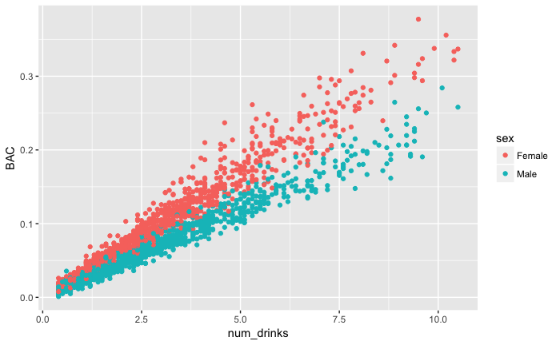

# To Dos

- Include URLs to clickable links
  - See “The Data” for my proposed method
[^1]: https://www.rdocumentation.org/packages/graphics/versions/3.4.3/topics/hist
[^2]: https://www.rdocumentation.org/packages/utils/versions/3.4.3/topics/read.table
[^3]: https://www.rdocumentation.org/packages/base/versions/3.4.3/topics/row.names
[^4]: https://www.rdocumentation.org/packages/utils/versions/3.4.3/topics/head
[^5]: https://www.rdocumentation.org/packages/utils/versions/3.4.3/topics/nrow
[^6]: https://www.rdocumentation.org/packages/utils/versions/3.4.3/topics/nrow
[^7]: http://www.ndaa.org/pdf/toxicology_final.pdf